# HBoV-1 Persistence Modeling

July, 21, 2017

Unfold code to see data processing steps

# R Packages Used

```r
library(xlsx)         # load .xlsx and .xls
library(lubridate)    # time and date functions
library(gridExtra)    # grid.arrange
library(xts)          # time-series objects and functions
library(knitr)
library(Rmisc)
library(DT)           # Javascript DataTables
library(sandwich)     # robust estimating equations for standard errors
library(visreg)       # visualize regressions
library(ggthemes)     # theme_tufte, theme_bw, etc.
library(gridExtra)    # arrange ggplot grobs
library(RColorBrewer) # plotting colors
library(forecast)     # moving averages, lags, forecasting
library(lattice)      # versatile plotting functions
library(magrittr)     # extra pipelines/infix operators (%<>%)
library(reshape2)     # melt and cast data, i.e. wide to long, long to wide
library(tidyverse)    # everything, including ggplot, dplyr, etc.
library(caret)        # model building and testing
library(msm)          # msm package carries 'deltamethod()'
```

# Data Loading

```r
setwd("S:/MartinEpi/Analysis/Bocavirus Persistence Modeling/")
test.results <- "bovtestresults_rich.xls"
test.results <- read.xlsx(test.results,
                          stringsAsFactors = FALSE, sheetIndex = 1)

test.results.pos <- "test_results_pos.xlsx"
test.results.pos <- read.xlsx(test.results.pos,
                              stringsAsFactors = FALSE, sheetIndex = 1)

diaries <- "diaries.csv"
diaries <- read.csv(diaries, stringsAsFactors = FALSE)

diary.pos <- "diary_pos.csv"
diary.pos <- read.csv(diary.pos, stringsAsFactors = FALSE)

main.long <- "main_long.csv"
main.long <- read.csv(main.long, stringsAsFactors = FALSE)

main <- "main.csv"
main <- read.csv(main, stringsAsFactors = FALSE)

results.dob <- "results_dob.csv"
results.dob <- read.csv(results.dob, stringsAsFactors = FALSE)

season.decomp <- "season_decomp.csv"
season.decomp <- read.csv(season.decomp, stringsAsFactors = FALSE)

durations <- "S:/MartinEpi/Analysis/Bocavirus Duration of Positivity/Excel Files/positive duration intervals.xlsx"
durations <- read.xlsx(durations, stringsAsFactors = FALSE, sheetIndex = 1)
```

Will a young child with a persistent bocavirus infection be protected from further illness? Can we find indicators of this in our dataset?

In order to gather evidence for our hypothesis we will perform three analyses, each with three sub-analyses:

1. Poisson Regression
   - count number of fevers over time given a child’s number of weeks of persistent infection. The offset will be the total number of weeks in the study.
2. Longitudinal Analysis via linear Mixed Modeling
3. Time Series Modeling to Account for Density of Time-Dependent Observations: GAM?

Alternatively, we want to examine re-infections using a 2-stage hidden markov model.

# Data Processing and Cleaning

```r
colnames(diaries) <- tolower(colnames(diaries))
colnames(diary.pos) <- tolower(colnames(diary.pos))
colnames(durations) <- tolower(colnames(durations))
colnames(main) <- tolower(colnames(main))
colnames(main.long) <- tolower(colnames(main.long))
colnames(results.dob) <- tolower(colnames(results.dob))
colnames(season.decomp) <- tolower(colnames(season.decomp))
colnames(test.results) <- tolower(colnames(test.results))
colnames(test.results.pos) <- tolower(colnames(test.results.pos))
colnames(durations) <- tolower(colnames(durations))
```

```r
test.results %<>%
  mutate(id = factor(patient),
         log_q_per_ml = log10(q_per_ml),
         date_ct = ave(as.numeric(id), id, FUN = seq_along))

test.results.pos %<>%
  mutate(id = factor(patient),
         q_per_ml = as.numeric(q_per_ml),
         log_q_per_ml = log10(q_per_ml),
         date_ct = ave(as.numeric(id), id, FUN = seq_along))

test.results.red <- test.results.pos %>% select(id, bovpos, date)

diaries %<>%
  mutate(id = factor(id),
         infant.dob = as.Date(infant.dob, format = "%d-%b-%y"),
         date = as.Date(date, format = "%d-%b-%y"))

diary.pos %<>%
  mutate(id = factor(id),
         date = as.Date(date, format = "%d-%b-%y"),
         infant.dob = as.Date(infant.dob, format = "%d-%b-%y"))

pcr.by.week <- diary.pos %>%
  select(id, date, pcr) %>%
  mutate(week = format(date, format = "%Y-%U")) %>%
  plyr::ddply(plyr::.(week, id), summarise,
              pcr.sum = sum(pcr, na.rm = TRUE))

# Gather only bocavirus positive children
id <- data.frame(id = factor(unique(test.results.pos$id)))

# Clean up main datasets
to_date <- c("date","infant.dob","stopdate","until.when","maternal.dob",
             "daycare.start", "daycare.end","play.start","play.end")
main %<>%
  mutate_at(to_date, funs(as.Date(., format = "%d-%b-%y"))) %>%
  mutate(id = factor(id),
         gender = factor(gender),
         maternal.dob = as.Date(ifelse(maternal.dob > "2000-01-01",
                                       format(maternal.dob, "19%y-%m-%d"),
                                       format(maternal.dob))),
         race_text = factor(race_text),
         play.group = factor(play.group),
         daycare.dur = as.numeric(difftime(daycare.end, daycare.start,
                                           units = "weeks"))) %>%
  rename(number.of.family.18.yrs = number.of.family..18.yrs)

dem.clin.dat <- main %>%
  select(id, gender, race, race_text, total.number.of.family,
                number.of.family.18.yrs, bf_duration, mom_age,
                siblings, breast_fed, day_care, seizure_hx, female, bf_length,
                daycare.start, daycare.end)

main.pos <- merge(id, main, by = "id")

to_date <- c("date","maternal.dob","infant.dob","stopdate",
             "until.when","daycare.start","daycare.end",
             "play.start","play.end")

main.long %<>%
  mutate_at(to_date, funs(as.Date(., format = "%d%B%Y"))) %>%
  mutate(id = factor(id),
         gender = factor(gender),
         race_text = factor(race_text),
         play.group = factor(play.group)) %>%
  rename(days.week.play = days.week..play.)

main.long <- merge(id, main.long, by = "id")

durations$id <- factor(durations$patient)

season.decomp$datetime <- as.Date(season.decomp$datetime, format = "%m/%d/%y")
```

```r
# Save .Rdata files. Done 'outside of markdown'
setwd("S:/MartinEpi/Analysis/Bocavirus Persistence Modeling/Rdata/")
saveRDS(dem.clin.dat, "dem_clin_dat.rds")
saveRDS(diaries, "diaries.rds")
saveRDS(diary.pos, "diary_pos.rds")
saveRDS(id, "pos_id.rds")
saveRDS(main, "main.rds")
saveRDS(main.long, "main_long.rds")
saveRDS(main.pos, "main_pos.rds")
saveRDS(pcr.by.week, "pcr_by_week.rds")
saveRDS(results.dob, "results_dob.rds")
saveRDS(season.decomp, "season_decomp.rds")
saveRDS(test.results.pos, "test_results_pos.rds")
saveRDS(durations, "durations.rds")
```

Load .Rdata files for speed and efficiency

```r
setwd("S:/MartinEpi/Analysis/Bocavirus Persistence Modeling/Rdata/")
dem.clin.dat <- readRDS("dem_clin_dat.rds")
diaries <- readRDS("diaries.rds")
diary.pos <- readRDS("diary_pos.rds")
id <- readRDS("pos_id.rds")
main <- readRDS("main.rds")
main.long <- readRDS("main_long.rds")
main.pos <- readRDS("main_pos.rds")
pcr.by.week <- readRDS("pcr_by_week.rds")
results.dob <- readRDS("results_dob.rds")
season.decomp <- readRDS("season_decomp.rds")
test.results.pos <- readRDS("test_results_pos.rds")
durations <- readRDS("durations.rds")
```

# Exploration

## Definitions of Persistent Infection

Three different definitions for duration of positivity

1. Primary infection criteria: no more than one interim negative specimen, at least two consecutive negatives for entry and exit
2. Same as definition 1, except now using the first date of infection as day 1 for BOV positive patients (often inflated)
3. Using the longest continuous infectious period for each patient, regardless of primary or later infection. No more than one interim negative specimen.

plotting patient 20 and 221 for illustration purposes

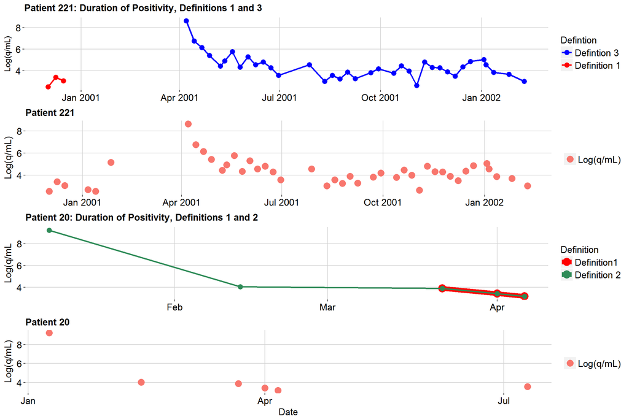

```r
pt20 <- test.results.pos[which(test.results.pos$id == 20), ]
pt20 <- pt20[complete.cases(pt20[,9]),]
pt20.def.1 <- filter(pt20,
                     date >= as.Date('1999-03-22') &
                       date <= as.Date('1999-04-06'))
pt20.def.2 <- filter(pt20,
                     date >= as.Date('1999-01-09') &
                       date <= as.Date('1999-04-06'))

pt221 <- test.results.pos[which(test.results.pos$id == 221), ]
pt221 <- pt221[complete.cases(pt221[,9]), ]
# split data set by infection period, by definition
pt221.def.1 <- filter(pt221, date == as.Date('2000-12-02') |
                        date == as.Date('2000-12-09') |
                        date == as.Date('2000-12-16'))
pt221.def.3 <- filter(pt221,
                      date >= as.Date('2001-04-07') &
                        date <= as.Date('2002-02-09'))

p <- pt221.def.1 %>%
  ggplot(aes(x = date, y = log_q_per_ml)) %>%
  add(geom_point(aes(color = "red"), size = 3.0)) %>%
  add(geom_line(aes(color = "red"), size = 1.0)) %>%
  add(geom_point(data = pt221.def.3,
                 aes(x = date, y = log_q_per_ml, color = "blue"),
                 size = 3.0)) %>%
  add(geom_line(data = pt221.def.3,
                aes(x = date, y = log_q_per_ml, group = 1, color = "blue"),
                size = 1.0)) %>%
  add(labs(x = "Date",
           y = "Log(q/mL)",
           title = "Patient 221: Duration of Positivity, Definitions 1 and 3")) %>%
  add(scale_color_manual(name = "Defintion",
                         values = c("red" = "red", "blue" = "blue"),
                         labels = c("Defintion 3", "Definition 1"))) %>%
  add(theme(legend.text = element_text(size = 13),
              legend.title = element_text(size = 13),
              axis.title.x = element_blank(),
              axis.text = element_text(size = 13, color = "black"),
              plot.title = element_text(size = 13, face = "bold"),
              panel.background = element_rect(fill = "white"),
              panel.grid.major = element_line(color = "lightgrey")))

p2 <- pt221 %>%
  ggplot(aes(x = date, y = log_q_per_ml), legend = TRUE) %>%
  add(geom_point(aes(color = "Log(q/mL)"), size = 4.0)) %>%
  add(labs(y = "Log(q/mL)",
           title = "Patient 221")) %>%
  add(theme(axis.title.x = element_blank(),
                axis.title.y = element_text(size = 13),
                legend.text = element_text(size = 13),
                legend.title = element_blank(),
                axis.text = element_text(size = 13, color = "black"),
                plot.title = element_text(size = 13, face = "bold"),
                panel.background = element_rect(fill = "white"),
                panel.grid.major = element_line(color = "lightgrey")))

q <- pt20 %>%
  ggplot(aes(x = date, y = log_q_per_ml)) %>%
  add(geom_point(data = pt20.def.1,
                 aes(x = date, y = log_q_per_ml, col = "red"),
                 size = 5.0)) %>%
  add(geom_line(data = pt20.def.1,
                aes(x = date, y = log_q_per_ml, col = "red"),
                size = 3.0, linetype = 1)) %>%
  add(geom_point(data = pt20.def.2,
                 aes(x = date, y = log_q_per_ml, col = "seagreen4"),
                 size = 3.0)) %>%
  add(geom_line(data = pt20.def.2,
                aes(x = date, y = log_q_per_ml, col = "seagreen4", group = 1),
                size = 1.0)) %>%
  add(labs(y = "Log(q/mL",
           x = "Date",
           title = "Patient 20: Duration of Positivity, Definitions 1 and 2")) %>%
  add(scale_color_manual(name = "Definition",
                         values = c("red" = "red", "seagreen4" = "seagreen4"),
                         labels = c("Definition1", "Definition 2"))) %>%
  add(theme(axis.title.y = element_text(size = 13),
              plot.title = element_text(size = 13, face = "bold"),
              axis.text = element_text(size = 13, color = "black"),
              legend.text = element_text(size = 13),
              legend.title = element_text(size = 13),
              axis.title.x = element_blank(),
              panel.background = element_rect(fill = "white"),
              panel.grid.major = element_line(color = "lightgrey")))

q2 <- pt20 %>%
  ggplot(aes(x = date, y = log_q_per_ml)) %>%
  add(geom_point(size = 4.0, aes(color = "Log(q/mL)"))) %>%
  add(labs(y = "Log(q/mL)",
           x = "Date",
           title = "Patient 20")) %>%
  add(theme(legend.text = element_text(size = 13),
                legend.title = element_blank(),
                axis.title.y = element_text(size = 13),
                axis.text = element_text(size = 13, color = "black"),
                plot.title = element_text(size = 13, face = "bold"),
                axis.title.x = element_text(size = 13),
                panel.background = element_rect(fill = "white"),
                panel.grid.major = element_line(color = "lightgrey")))

grid.arrange(p, p2, q, q2, nrow = 4)
```

# Modelling

## Poisson Regression

The form of the generalized linear model:
$$g(\mu_i)=\beta_0+\beta_1x_{1,i}+...+\beta_kx_{k,i}$$
with *Random Component*:
$$Y \sim Poisson(t_i\mu_i)$$
where t is the offset of time, more specifically, the expectation of *Y/t*, is $\mu$,
$$E[Y/t]=\mu$$
And the *Systematic Component*: Any set of $X_i=(x_{1,i},x_{2,i},...,x_{k,i})$ covariates And the *Link* function:
$$log(Y/t)$$
The regression model for the expected rate of the occurrence of fevers in our set-up is:
$$log(t_i\mu_i) = \beta_0 + \beta_{1}*(Weeks of Infection_i)$$
- Or -
$$log(\mu_i) = \beta_0 + \beta_{1,i}*(Weeks of Infection_i) + log(t_i)$$

First need to count total number of weeks each patient was in the study, for the offset

```r
max.weeks <- aggregate(age_week ~ id, main.long, max)
max.weeks <- merge(max.weeks, id, by = "id")
glimpse(max.weeks)
```

```
## Observations: 66
## Variables: 2
## $ id       <fctr> 107, 115, 135, 147, 151, 155, 159, 161, 162, 163, 16...
## $ age_week <int> 106, 99, 105, 105, 106, 106, 108, 113, 106, 105, 106,...
```

```r
max.days <- aggregate(age_week * 7 ~ id, main.long, max)
colnames(max.days) <- c("id","study_time")
max.days <- merge(max.days, id, by = "id")
glimpse(max.days)
```

```
## Observations: 66
## Variables: 2
## $ id         <fctr> 107, 115, 135, 147, 151, 155, 159, 161, 162, 163, ...
## $ study_time <dbl> 742, 693, 735, 735, 742, 742, 756, 791, 742, 735, 7...
```

Now we need to count total number of fevers by ID

```r
fever.count <- aggregate(fever ~ id, diary.pos, sum, na.rm = TRUE)
glimpse(fever.count)
```

```
## Observations: 66
## Variables: 2
## $ id    <fctr> 20, 23, 29, 82, 83, 91, 92, 98, 107, 115, 135, 147, 151...
## $ fever <int> 2, 14, 20, 7, 37, 5, 7, 8, 16, 15, 7, 8, 6, 14, 15, 3, 1...
```

To get a final data set for poisson regression, we will merge everything together

```r
all.df <- Reduce(function(x,y){merge(x, y, all = TRUE)},
                 list(max.days,
                      fever.count,
                      main.pos,
                      durations[,grep("interval|id", names(durations))]))
# main <- merge(merge(max.weeks, fever.count, by="id", all=TRUE), main.pos, by="id", all=TRUE)
```

The three main components are, 1. the number of fevers incurred by the children over time 2. number of days in the study (offset) 3. number of days of persistent infection

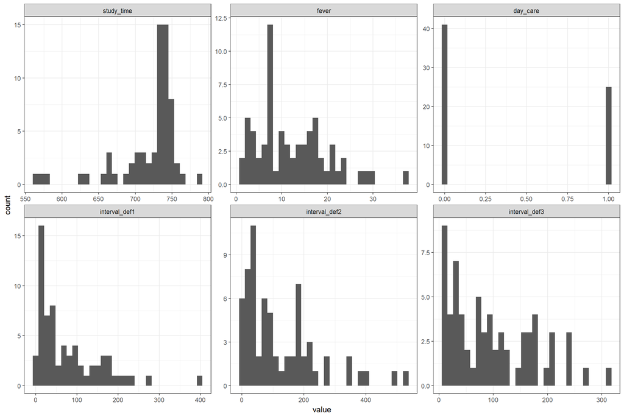

```r
df.reduced <- all.df %>%
  select(study_time, fever, day_care,
         interval_def1, interval_def2, interval_def3)

df.reduced %>%
  mutate(id = as.numeric(rownames(df.reduced))) %>%
  melt(id = "id") %>%
  ggplot(aes(x = value)) %>%
  add(geom_histogram(aes(x = value))) %>%
  add(facet_wrap(~variable, scales = "free")) %>%
  add(theme_bw())
```

Most children in the study were followed for two years with a median follow-up time of which is roughly $52*2*7 = 728$, the number of days in two years. The median number of fevers over time is 10.5 while the median duration of “persistent infection” for each definition was 43.5, 84.5, and 80.5, respectively

Comparing HBoV-1 infections in newborns from Kampala, Uganda and Seattle, Washington US.

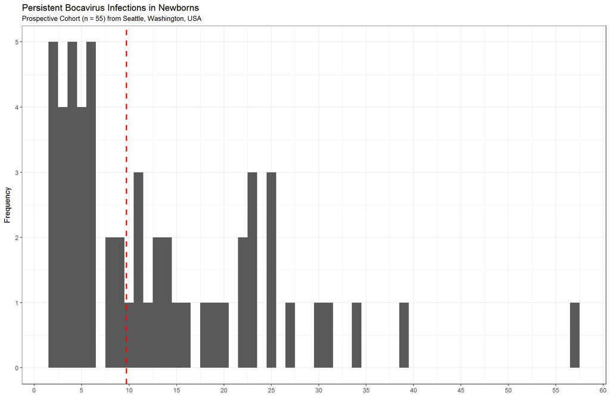

```r
durations %>%
  select(first_date_def1, end_date_def1_and_2) %>%
  mutate(interval = as.numeric(difftime(end_date_def1_and_2,
                                        first_date_def1,
                                        units = "weeks"))) %>%
  filter(interval >= 2.0) %>%
  ggplot() %>%
  add(geom_histogram(aes(x = interval), binwidth = 1)) %>%
  add(geom_vline(aes(xintercept = median(interval, na.rm = TRUE)),
                 color = "red", linetype = "dashed", size = 1)) %>%
  add(scale_x_continuous(breaks = seq(from = 0, to = 60, by = 5))) %>%
  add(theme_bw()) %>%
  add(labs(x = "",
           y = "Frequency",
           title = "Persistent Bocavirus Infections in Newborns",
           subtitle = "Prospective Cohort (n = 55) from Seattle, Washington, USA"))
```

```r
f <- function(x){
  mean = mean(x, na.rm = TRUE)
  sd = sd(x, na.rm = TRUE)
  median = median(x, na.rm = TRUE)
  minimum = min(x, na.rm = TRUE)
  maximum = max(x, na.rm = TRUE)
  n = length(x)
  rbind(mean, sd, median, minimum, maximum, n)
}

data.frame(lapply(df.reduced, f))
```

```
##         study_time     fever   day_care interval_def1 interval_def2
## mean     718.77273 12.151515  0.3787879      78.50000      123.7576
## sd        44.35965  7.774203  0.4888024      79.21718      121.7566
## median   735.00000 10.500000  0.0000000      43.50000       84.5000
## minimum  567.00000  1.000000  0.0000000       4.00000        4.0000
## maximum  791.00000 37.000000  1.0000000     402.00000      533.0000
## n         66.00000 66.000000 66.0000000      66.00000       66.0000
##         interval_def3
## mean         97.59091
## sd           76.64202
## median       80.50000
## minimum       6.00000
## maximum     308.00000
## n            66.00000
```

Only consider those with a duration >= 14 days (two weeks)

```r
temp <- df.reduced %>%
  select(interval_def1, interval_def2, interval_def3) %>%
  mutate(interval_def1 = ifelse(interval_def1 < 14, NA, interval_def1),
         interval_def2 = ifelse(interval_def2 < 14, NA, interval_def2),
         interval_def3 = ifelse(interval_def3 < 14, NA, interval_def3))

data.frame(lapply(temp, f))
```

```
##         interval_def1 interval_def2 interval_def3
## mean         92.72727      137.5593     108.16949
## sd           79.46941      121.5980      74.22221
## median       68.00000       96.0000      92.00000
## minimum      14.00000       14.0000      15.00000
## maximum     402.00000      533.0000     308.00000
## n            66.00000       66.0000      66.00000
```

```r
rm(temp)
```

Run Models

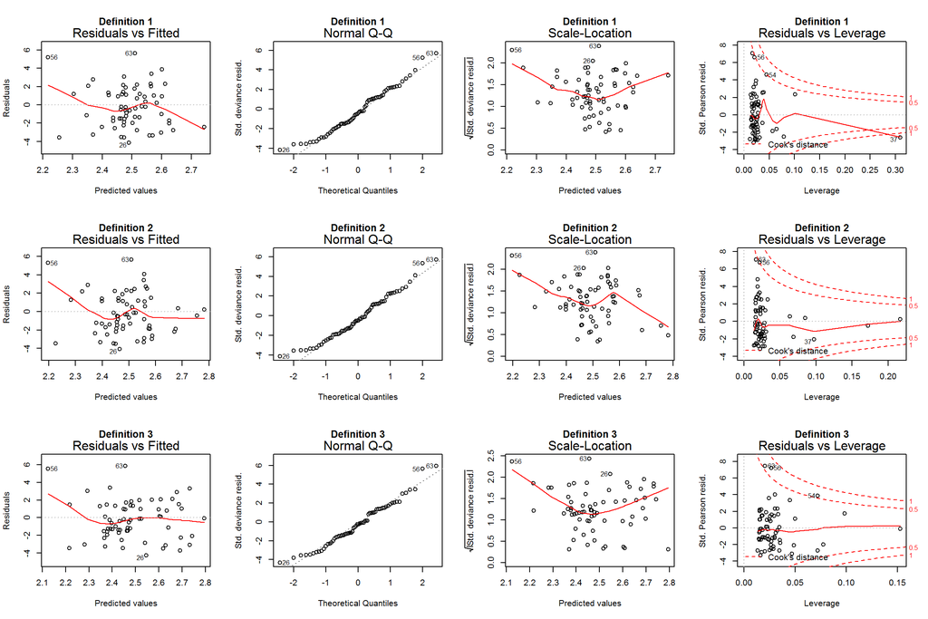

```r
model.def.1 <- glm(fever ~ interval_def1 + offset(log(study_time)),
                   family = poisson, data = df.reduced)
model.def.2 <- glm(fever ~ interval_def2 + offset(log(study_time)),
                   family = poisson, data = df.reduced)
model.def.3 <- glm(fever ~ interval_def3 + offset(log(study_time)),
                   family = poisson, data = df.reduced)

par(mfrow = c(3, 4))
plot(model.def.1, main = "Definition 1")
plot(model.def.2, main = "Definition 2")
plot(model.def.3, main = "Definition 3")
```

```r
par(mfrow = c(1, 1))
```

Cameron and Trivedi (2009) recommended using robust standard errors for the parameter estimates to control for mild violation of the distribution assumption that the variance equals the mean. The R package sandwich is used below to obtain the robust standard errors and the p-values. Together with the p-values, we have also calculated the 95% confidence interval using the parameter estimates and their robust standard errors

```r
robustErrors <- function(model.object) {
  # Heteroskedasticity-consistent estimation of the covariance matrix
  cov.ml <- vcovHC(model.object, type = "HC0")
  std.err <- sqrt(diag(cov.ml))
  r.est.1 <- cbind(
    Estimate = coef(model.object),
    model.se = summary(model.object)$coefficients[, 2],
    "Robust SE" = std.err,
    "Pr(>|Z|)" = 2*pnorm(abs(coef(model.object)/std.err), lower.tail = FALSE),
    LB = coef(model.object) - 1.96*std.err,
    UB = coef(model.object) + 1.96*std.err
    )
  r.est.1
}

models <- list(model.def.1, model.def.2, model.def.3)

lapply(models, robustErrors)
```

```
## [[1]]
##                    Estimate     model.se    Robust SE      Pr(>|Z|)
## (Intercept)   -4.1410917149 0.0502396453 0.1130406064 8.329525e-294
## interval_def1  0.0007543893 0.0004288087 0.0009621461  4.329994e-01
##                         LB           UB
## (Intercept)   -4.362651303 -3.919532126
## interval_def1 -0.001131417  0.002640196
##
## [[2]]
##                    Estimate     model.se  Robust SE  Pr(>|Z|)
## (Intercept)   -4.1608872219 0.0511752715 0.10923476 0.0000000
## interval_def2  0.0006262742 0.0002765479 0.00043659 0.1514388
##                          LB           UB
## (Intercept)   -4.3749873534 -3.946787090
## interval_def2 -0.0002294421  0.001481991
##
## [[3]]
##                   Estimate     model.se   Robust SE      Pr(>|Z|)
## (Intercept)   -4.241006559 0.0595022928 0.138911321 1.032180e-204
## interval_def3  0.001573696 0.0004474529 0.001004628  1.172443e-01
##                          LB           UB
## (Intercept)   -4.5132727481 -3.968740369
## interval_def3 -0.0003953756  0.003542767
```

To obtain incident rate ratio versions of our estimates we will turn to the delta method:

The delta method expands a differentiable function of a random variable about its mean, usually with a first-order Taylor approximation, and then takes the variance

```r
rateRatios1 <- function(model.object) {
  require(msm)
  cov.ml <- vcovHC(model.object, type = "HC0")
  r.est.1 <- robustErrors(model.object)
  s <- deltamethod(list(~exp(x1), ~ exp(x2)), coef(model.object), cov.ml)
  rexp.est.1 <- exp(r.est.1[, -4]) # removing (uncorrected) p-values
  rexp.est.1[,"Robust SE"] <- s
  rexp.est.1
}

lapply(models, rateRatios1)
```

```
## [[1]]
##                 Estimate model.se    Robust SE         LB         UB
## (Intercept)   0.01590548 1.051523 0.0017979649 0.01274455 0.01985038
## interval_def1 1.00075467 1.000429 0.0009628722 0.99886922 1.00264368
##
## [[2]]
##                 Estimate model.se    Robust SE        LB         UB
## (Intercept)   0.01559372 1.052507 0.0017033759 0.0125883 0.01931666
## interval_def2 1.00062647 1.000277 0.0004368635 0.9997706 1.00148309
##
## [[3]]
##                Estimate model.se   Robust SE         LB         UB
## (Intercept)   0.0143931 1.061308 0.001999364 0.01096252 0.01889722
## interval_def3 1.0015749 1.000448 0.001006211 0.99960470 1.00354905
```

Plotting

Predictive curves

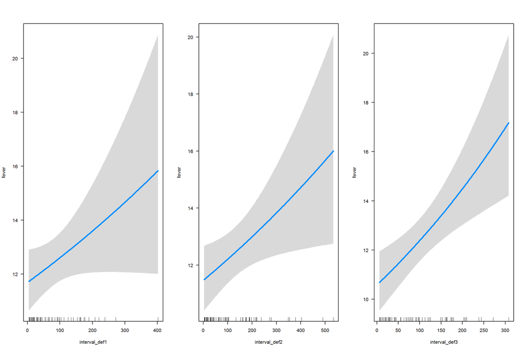

```r
par(mfrow = c(1, 3))
visreg(model.def.1, "interval_def1", scale = "response")
visreg(model.def.2, "interval_def2", scale = "response")
visreg(model.def.3, "interval_def3", scale = "response")
```

```r
par(mfrow = c(1, 1))
```

Those are all very similar looking

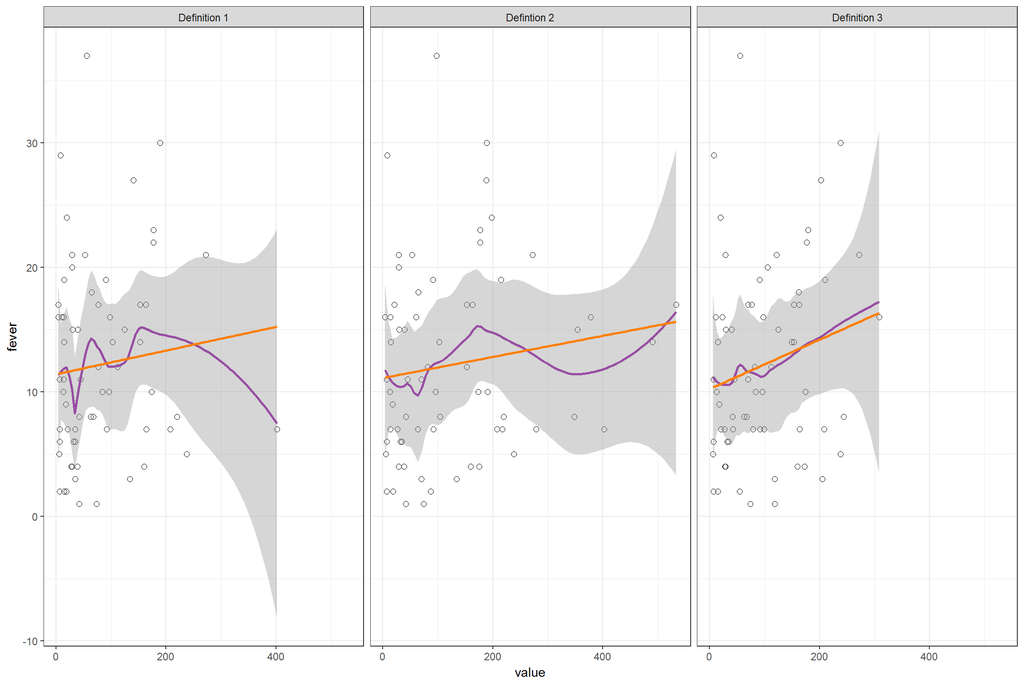

```r
model.def.1 <- glm(fever ~ interval_def1 + day_care + offset(log(study_time)),
                   family = poisson,
                   data = df.reduced)
model.def.2 <- glm(fever ~ interval_def2 + day_care + offset(log(study_time)),
                   family = poisson,
                   data = df.reduced)
model.def.3 <- glm(fever ~ interval_def3 + day_care + offset(log(study_time)),
                   family = poisson,
                   data = df.reduced)

models <- list(model.def.1, model.def.2, model.def.3)

lapply(models, robustErrors)
```

```
## [[1]]
##                    Estimate     model.se    Robust SE      Pr(>|Z|)
## (Intercept)   -4.1280457909 0.0549724353 0.1331481627 4.850651e-211
## interval_def1  0.0007915973 0.0004347663 0.0009460539  4.027410e-01
## day_care      -0.0427477950 0.0738395390 0.1504795831  7.763513e-01
##                         LB           UB
## (Intercept)   -4.389016190 -3.867075392
## interval_def1 -0.001062668  0.002645863
## day_care      -0.337687778  0.252192188
##
## [[2]]
##                    Estimate     model.se    Robust SE      Pr(>|Z|)
## (Intercept)   -4.1473279972 0.0563516327 0.1318195703 2.862581e-217
## interval_def2  0.0006420382 0.0002776667 0.0004223902  1.285080e-01
## day_care      -0.0414965595 0.0733909679 0.1504953499  7.827530e-01
##                          LB           UB
## (Intercept)   -4.4056943550 -3.888961639
## interval_def2 -0.0001858467  0.001469923
## day_care      -0.3364674454  0.253474326
##
## [[3]]
##                   Estimate     model.se   Robust SE      Pr(>|Z|)
## (Intercept)   -4.221613186 0.0618640767 0.151120806 9.931139e-172
## interval_def3  0.001693396 0.0004609706 0.000996218  8.916395e-02
## day_care      -0.084261071 0.0750483346 0.145518884  5.625630e-01
##                          LB           UB
## (Intercept)   -4.5178099644 -3.925416407
## interval_def3 -0.0002591915  0.003645983
## day_care      -0.3694780829  0.200955941
```

```r
rateRatios2 <- function(model.object) {
  cov.ml <- vcovHC(model.object, type = "HC0")
  r.est.1 <- robustErrors(model.object)
  s <- deltamethod(list(~exp(x1), ~ exp(x2), ~exp(x3)), coef(model.object), cov.ml)
  rexp.est.1 <- exp(r.est.1[, -4]) # removing (uncorrected) p-values
  rexp.est.1[,"Robust SE"] <- s
  rexp.est.1
}

lapply(models, rateRatios2)
```

```
## [[1]]
##                 Estimate model.se    Robust SE         LB         UB
## (Intercept)   0.01611434 1.056511 0.0021455946 0.01241294 0.02091946
## interval_def1 1.00079191 1.000435 0.0009468031 0.99893790 1.00264937
## day_care      0.95815301 1.076634 0.1441824655 0.71341800 1.28684333
##
## [[2]]
##                Estimate model.se    Robust SE         LB         UB
## (Intercept)   0.0158066 1.057970 0.0020836186 0.01220763 0.02046659
## interval_def2 1.0006422 1.000278 0.0004226615 0.99981417 1.00147100
## day_care      0.9593526 1.076151 0.1443781107 0.71428914 1.28849430
##
## [[3]]
##                 Estimate model.se    Robust SE        LB         UB
## (Intercept)   0.01467495 1.063818 0.0022176906 0.0109129 0.01973392
## interval_def3 1.00169483 1.000461 0.0009979064 0.9997408 1.00365264
## day_care      0.91919125 1.077936 0.1337596847 0.6910949 1.22257091
```

Diagnostics

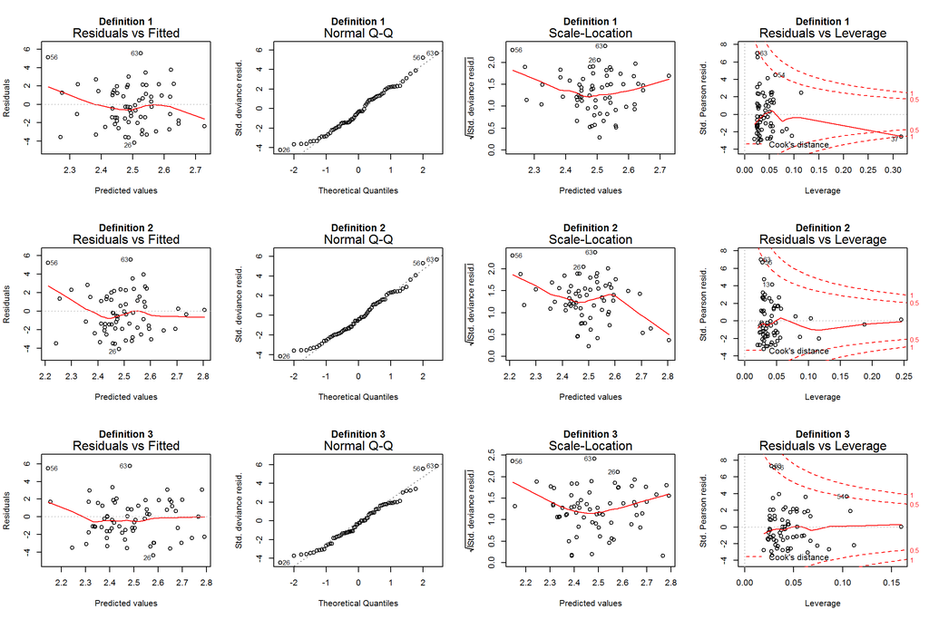

```r
par(mfrow = c(3, 4))
plot(model.def.1, main = "Definition 1")
plot(model.def.2, main = "Definition 2")
plot(model.def.3, main = "Definition 3")
```

```r
par(mfrow = c(1, 1))
```

Stratifying by those in daycare attendance

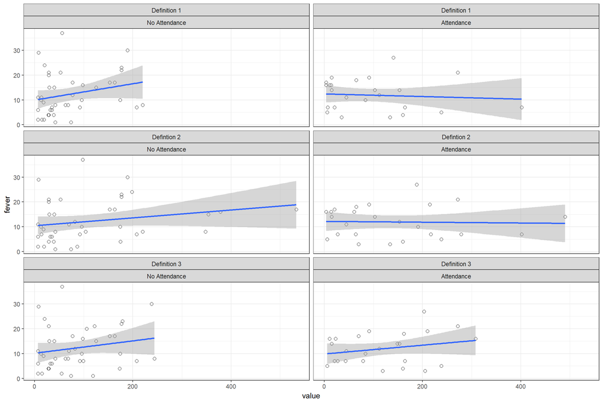

```r
df.reduced %>%
  select(fever, contains('interval'), day_care) %>%
  melt(id = c("fever","day_care")) %>%
  mutate(variable = factor(variable,
                           levels = c("interval_def1", "interval_def2", "interval_def3"),
                           labels = c("Definition 1", "Defintion 2", "Definition 3")),
         day_care = factor(day_care,
                           levels = c(0, 1),
                           labels = c("No Attendance","Attendance"))) %>%
  ggplot(aes(x = value)) %>%
  add(geom_point(aes(y = fever), shape = 1, size = 2)) %>%
  add(geom_smooth(aes(y = fever), method = "glm")) %>%
  add(facet_wrap( ~ variable + day_care, ncol = 2)) %>%
  add(theme_bw())
```

## Longitudinal Approach

### Investigating seasonality in HBoV-1 incidence

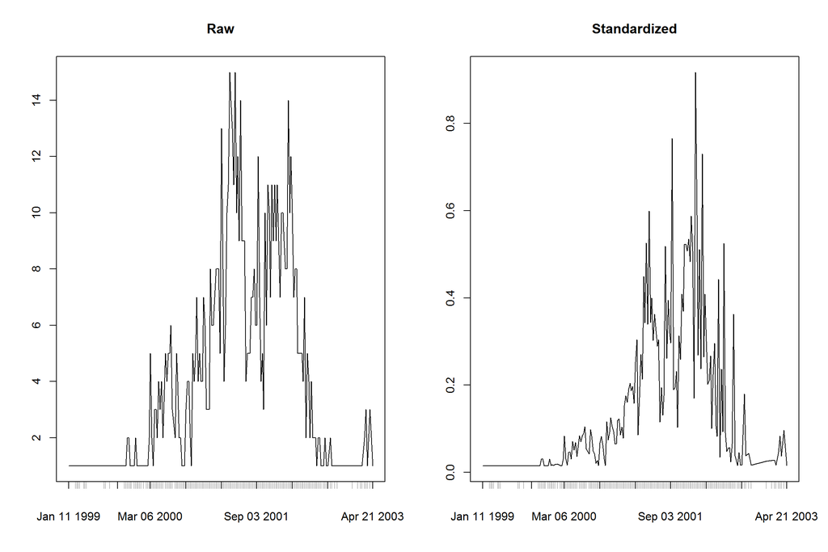

```r
# test.results.pos %>%
#   dplyr::select(date_ct, id, log_q_per_ml) %>%
#   dplyr::mutate(log_q_per_ml = ifelse(is.na(log_q_per_ml), 0, log_q_per_ml)) %>%
#   ggplot(aes(x = date_ct)) %>%
#   add(geom_point(aes(y = log_q_per_ml), color = "blue")) %>%
#   add(labs(x = "Collection Date",
#            y = "Log q/mL HBoV-1")) %>%
#   add(theme_bw()) -> p
#
# pdf("S:/MartinEpi/Analysis/Bocavirus Persistence Modeling/plots and figures/all_folks.pdf")
# ggplus::facet_multiple(plot = p, facets = "id", ncol = 2, nrow = 4, scales = "free_x")
# dev.off()

temp <- test.results.pos %>%
  select(date_ct) %>%
  count(date_ct) %>%
  rename(n.enroll = n)

hbov.ts <- test.results.pos %>%
  full_join(temp, by = "date_ct") %>%
  select(date, bovpos, n.enroll) %>%
  filter(bovpos != 0) %>%
  arrange(date) %>%
  mutate(bov = bovpos/n.enroll)

cutXtsObjByWeek <- function(x, date, colname) {
  # first, sum by day so there are no duplicate days
  cut.frame <- aggregate(x ~ cut(date, "day"),
                         FUN = sum, na.rm = TRUE)
  # change colnames, aggregate makes them ugly
  colnames(cut.frame) <- c("date", as.character(colname))
  # reformat date variable, aggregate converts to string
  cut.frame$date <- as.Date(cut.frame$date, format = "%Y-%m-%d")
  # make 'weeks' of data
  cut.frame$week <- floor_date(cut.frame$date, "week") + 8
  # sum `colname` by week
  summarized <- aggregate(cut.frame[,colname] ~ cut.frame[,"week"],
                          FUN = sum, na.rm = TRUE)
  colnames(summarized) <- c("week","sumObj")
  xts.obj <- xts(summarized$sumObj, order.by = summarized$week)
}

hbov.std.xts <- cutXtsObjByWeek(x = hbov.ts$bov, date = hbov.ts$date, colname = "hbov")
hbov.xts <- cutXtsObjByWeek(x = hbov.ts$bovpos, date = hbov.ts$date, colname = "hbov")

par(mfrow = c(1, 2))
plot(hbov.xts, auto.grid = FALSE, main = "Raw")
plot(hbov.std.xts, auto.grid = FALSE, main = "Standardized")
```

```r
par(mfrow = c(1, 1))
```

The difference between these last two plots is in proportion. On the left, ‘raw’ is the incidence of HBoV-1 (+) samples by date while ‘standardized’ is the resulting plot when dividing ‘raw’ by the number enrolled at that time point. Which is described by the following plot:

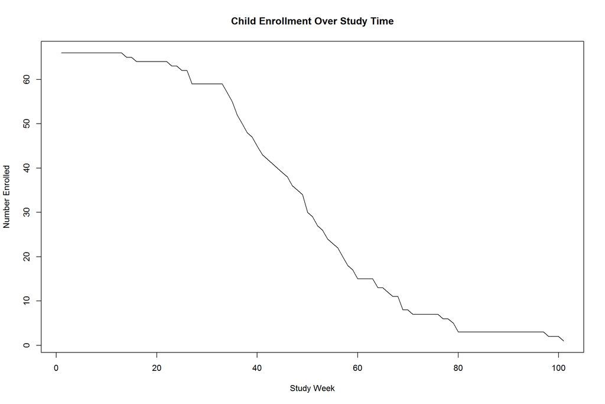

```r
with(temp, {
  plot(date_ct,
       n.enroll,
       type = "l",
       main = "Child Enrollment Over Study Time",
       xlab = "Study Week",
       ylab = "Number Enrolled")
})
```

The take-away is that there does not appear to be any seasonality in Bocavirus incidence during this study time.

Investigating seasonality in fever incidence

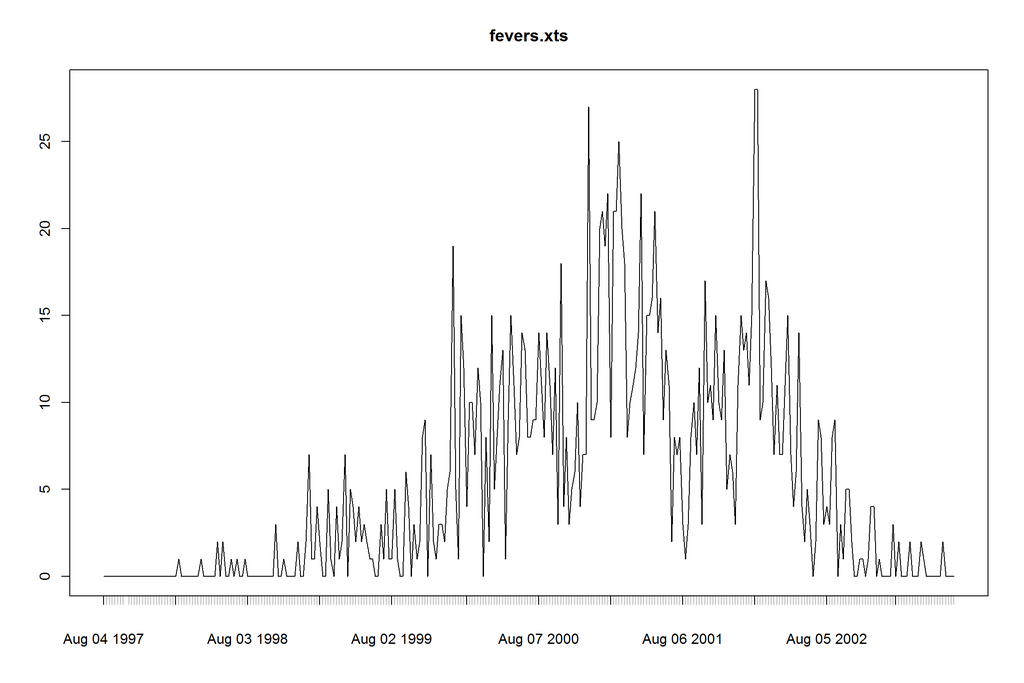

```r
fevers <- diaries %>%
  filter(!is.na(fever)) %>%
  select(date, fever) %>%
  arrange(date)

fevers.xts <- cutXtsObjByWeek(x = fevers$fever,
                              date = fevers$date,
                              colname = "fever")

plot(fevers.xts, auto.grid = FALSE)
```

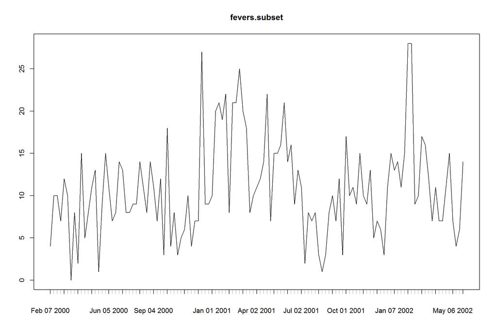

```r
# Window/subset to time-periods with greater numbers of individuals

fevers.subset <- fevers.xts["2000-02-01/2002-06-01"]
plot(fevers.subset, auto.grid = FALSE)
```

Simple moving averages of the ‘mean fevers by study week’

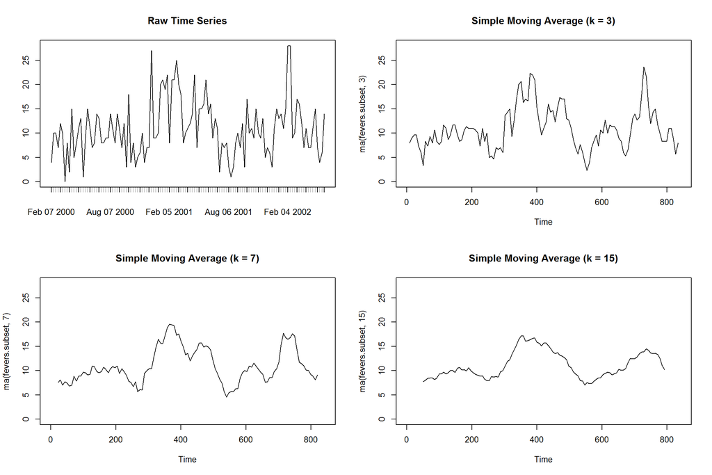

```r
par(mfrow = c(2, 2))
ylim <- c(min(fevers.subset), max(fevers.subset))
plot(fevers.subset, main = "Raw Time Series", auto.grid = FALSE)
plot(ma(fevers.subset, 3), main = "Simple Moving Average (k = 3)", ylim = ylim)
plot(ma(fevers.subset, 7), main = "Simple Moving Average (k = 7)", ylim = ylim)
plot(ma(fevers.subset, 15), main = "Simple Moving Average (k = 15)", ylim = ylim)
```

```r
par(mfrow = c(1, 1))
```

Data do not appear seasonal, here we are trying to investigate seasonality but will come up short

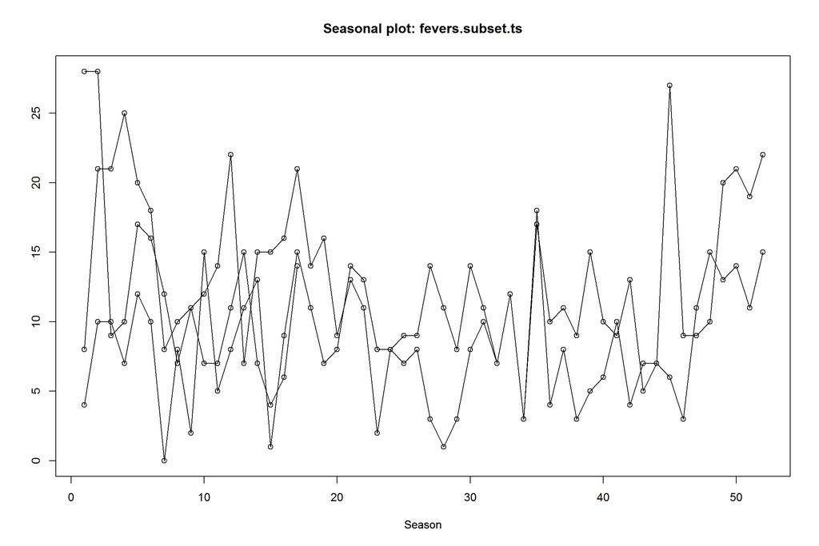

```r
fevers.subset.ts <- ts(fevers.subset, start = start(fevers.subset), f = 52)

seasonplot(fevers.subset.ts) # failure: no seasonal component
```

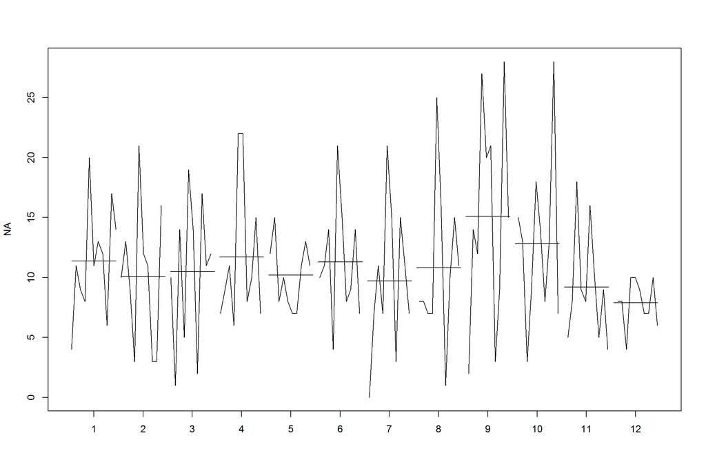

```r
monthplot(fevers.subset)
```

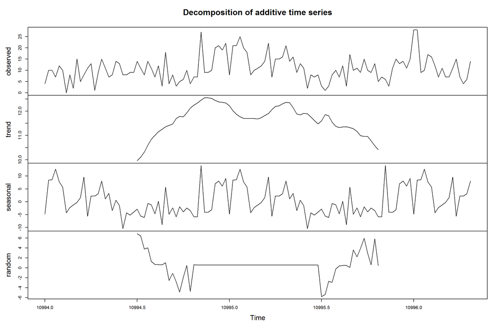

```r
# but wait, there's more
fever.decomp <- decompose(fevers.subset.ts, type = "additive")
plot(fever.decomp) # definitely doesn't appear to be seasonal
```

Let’s try with the full symptom data, this should be seasonal

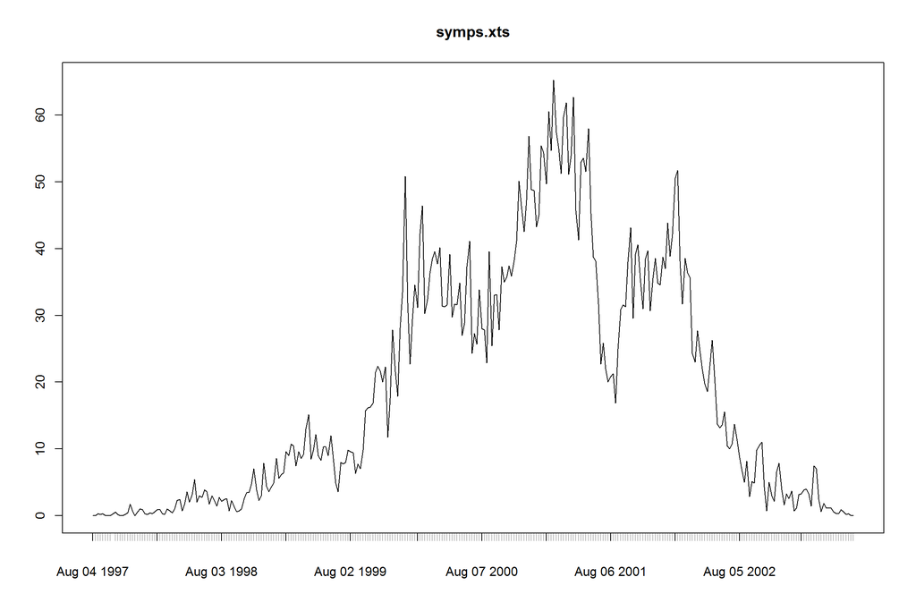

```r
symps <- arrange(select(diaries, date, symp_ct), date)
symps <- aggregate(symp_ct ~ cut(symps$date, "day"),
                   data = symps,
                   FUN = sum,
                   na.rm = TRUE)
colnames(symps) <- c("date", "symp_ct")

symps$date <- as.Date(symps$date, format = "%Y-%m-%d")
symps$week <- floor_date(symps$date, "week") + 8

symps.mean.wk <- ddply(symps, .(week), summarize, meanSymps = mean(symp_ct))
symps.xts <- xts(symps.mean.wk$meanSymps, order.by = symps.mean.wk$week)
plot(symps.xts, auto.grid = FALSE)
```

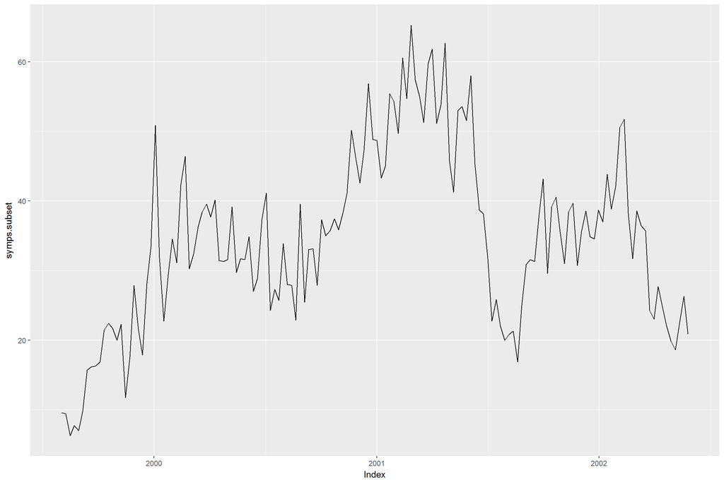

```r
# Window/subset to time-periods with greater numbers of individuals

symps.subset <- symps.xts["1999-08-01/2002-06-01"]
autoplot(symps.subset)
```

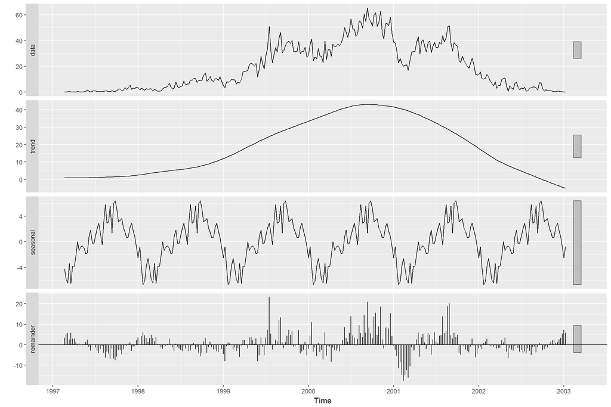

```r
symptoms.stl <- stl(ts(symps.mean.wk$meanSymps,
                       start = c(1997, 8, 4),
                       freq = 52),
                    s.window = "periodic",
                    robust = TRUE)
autoplot(symptoms.stl)
```

We can definitely see seasonal effects in the data with [Rob J. Hyndman’s](https://robjhyndman.com/) stl decomposition functions.

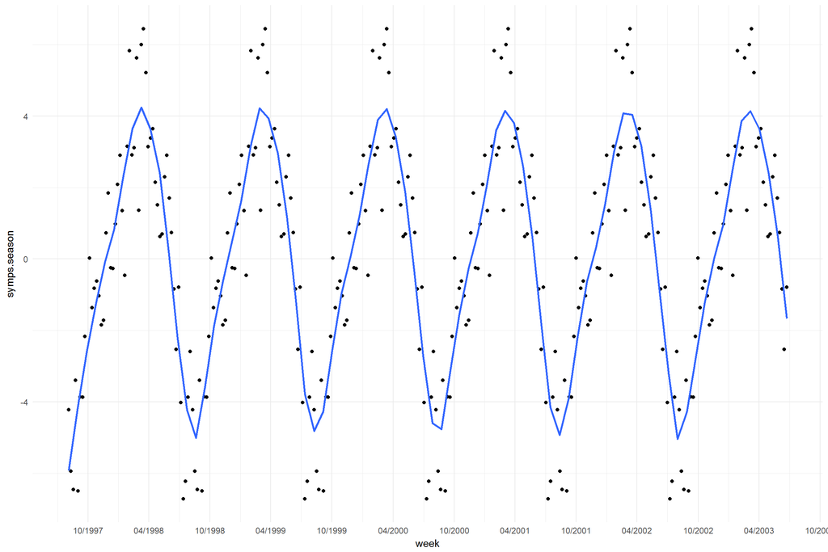

```r
season.decomp <- data.frame(week = symps.mean.wk$week,
                            symps.season = as.numeric(symptoms.stl$time.series[,"seasonal"]))

season.decomp %>%
  ggplot(aes(x = week)) %>%
  add(geom_point(aes(y = symps.season))) %>%
  add(stat_smooth(aes(y = symps.season),
                  method = "loess", span = 0.1, se = FALSE)) %>%
  add(scale_x_date(date_breaks = "6 months", date_labels = "%m/%Y")) %>%
  add(theme_minimal())
```

Eventually, we will adjust for the ‘ill-season’ effect in our final model, here average by month and year and save it.

```r
symptoms.agg <- season.decomp %>%
  mutate(year.mon = floor_date(week, "month")) %>%
  plyr::ddply("year.mon", summarise, symps.season = mean(symps.season))
```

### Tidying data for longitudinal modelling

```r
dem.dur <- dem.clin.dat %>%
  right_join(durations, by = "id") %>%
  select(-patient) %>%
  mutate(id = factor(id))

# defined as >= 2 of the following: fever, cough, runnynose,
# vomit, diarrhea, general.rash, local.rash, diaper.rash, fussy,
# seizure, drvisit
ill.symptoms.df <- diaries %>%
  mutate(drvisit = ifelse(drvisit == 5, 1, drvisit),
         ill.symptoms = rowSums(.[c(6,8:17)], na.rm = TRUE)) %>%
  select(id, date, ill.symptoms) %>%
  arrange(id, date)

ill.symptoms.df <- aggregate(ill.symptoms ~ cut(ill.symptoms.df$date, "day") + id,
                             data = ill.symptoms.df,
                             FUN = sum,
                             na.rm = TRUE)
colnames(ill.symptoms.df) <- c("date", "id", "ill.symptoms")

dem.dur.symp.long <- ill.symptoms.df %>%
  mutate(date = as.Date(date, format = "%Y-%m-%d")) %>%
  right_join(dem.dur, by = "id") %>%
  mutate(id = factor(id))

# just fevers

fevers <- diaries %>%
  select(id, date, fever) %>%
  arrange(date)

fevers <- aggregate(fever ~ cut(fevers$date, "day") + id,
                    data = fevers,
                    FUN = sum,
                    na.rm = TRUE)
colnames(fevers) <- c("date","id", "fever")
fevers <- mutate(fevers, date = as.Date(date, format = "%Y-%m-%d"))

dem.dur.fever.long <- fevers %>%
  right_join(dem.dur, by = "id") %>%
  mutate(id = factor(id))
```

Subsetting by fever dates and persistent infection duration (start and ending)

```r
cutToDuration <- function(df, def.date, symp, cutIll = FALSE) {
  require(dplyr)
  filtered <- filter(df, as.Date(df$date) >= as.Date(df[,def.date]))
  filtered$week <- floor_date(filtered$date, "week")
  aggregated <- aggregate(filtered[,symp] ~ filtered$week + filtered$id, FUN = sum)
  colnames(aggregated) <- c("week","id", symp)
  merged <- dem.clin.dat %>%
    right_join(aggregated, by = "id") %>%
    mutate(id = factor(id),
           year.mon = floor_date(week, "month"))
  if (cutIll) {
    merged[,symp][merged[,symp] < 2] <- 0
  }
  merged
}

# Fevers
fever.dat.def.1 <- cutToDuration(dem.dur.fever.long,
                                 def.date = "first_date_def1",
                                 symp = "fever")
fever.dat.def.2 <- cutToDuration(dem.dur.fever.long,
                                 def.date = "first_date_def2",
                                 symp = "fever")
fever.dat.def.3 <- cutToDuration(dem.dur.fever.long,
                                 def.date = "first_date_def3",
                                 symp = "fever")
# Illness symptoms
ill.dat.def.1 <- cutToDuration(dem.dur.symp.long,
                               def.date = "first_date_def1",
                               symp = "ill.symptoms",
                               cutIll = TRUE)
ill.dat.def.2 <- cutToDuration(dem.dur.symp.long,
                               def.date = "first_date_def2",
                               symp = "ill.symptoms",
                               cutIll = TRUE)
ill.dat.def.3 <- cutToDuration(dem.dur.symp.long,
                               def.date = "first_date_def3",
                               symp = "ill.symptoms",
                               cutIll = TRUE)
```

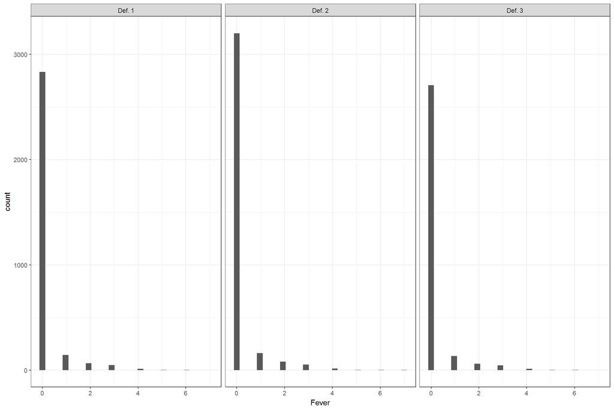

```r
reduceFunction <- function(df, def, symp) {
  ct <- df[,symp]
  id <- as.numeric(rownames(df))
  def <- as.character(def)
  func.df <- data.frame(ct = ct,
                        id = id,
                        def = def)
}

df1 <- reduceFunction(fever.dat.def.1, def = "Def. 1", symp = "fever")
df2 <- reduceFunction(fever.dat.def.2, def = "Def. 2", symp = "fever")
df3 <- reduceFunction(fever.dat.def.3, def = "Def. 3", symp = "fever")

df <- data.frame(rbind(df1, df2, df3))

df %>%
  ggplot() %>%
  add(geom_histogram(aes(x = ct))) %>%
  add(facet_wrap( ~def, scales = "fixed")) %>%
  add(labs(x = "Fever")) %>%
  add(theme_bw())
```

```r
rm(df, df1, df2, df3)
```

They look almost exactly alike, the distributions will differ though. If we simply don’t have enough fevers on record we may enumerate more symptoms

### Time-Dependent Covariate Generation

Add seasonal effect

```r
fever.dat.def.1 <- left_join(fever.dat.def.1, symptoms.agg, by = "year.mon")
fever.dat.def.2 <- left_join(fever.dat.def.2, symptoms.agg, by = "year.mon")
fever.dat.def.3 <- left_join(fever.dat.def.3, symptoms.agg, by = "year.mon")

ill.dat.def.1 <- left_join(ill.dat.def.1, symptoms.agg, by = "year.mon")
ill.dat.def.2 <- left_join(ill.dat.def.2, symptoms.agg, by = "year.mon")
ill.dat.def.3 <- left_join(ill.dat.def.3, symptoms.agg, by = "year.mon")
```

Make a time-varying covariate for daycare attendance

```r
# fevers
fever.dat.def.1 %<>%
  mutate(daycare_dummy = ifelse((as.Date(daycare.start) <= as.Date(week)) &
                                  (as.Date(week) <= as.Date(daycare.end)), 1, 0))
fever.dat.def.2 %<>%
  mutate(daycare_dummy = ifelse((as.Date(daycare.start) <= as.Date(week)) &
                                  (as.Date(week) <= as.Date(daycare.end)), 1, 0))
fever.dat.def.3 %<>%
  mutate(daycare_dummy = ifelse((as.Date(daycare.start) <= as.Date(week)) &
                                  (as.Date(week) <= as.Date(daycare.end)), 1, 0))

# illness symptoms
ill.dat.def.1 %<>%
  mutate(daycare_dummy = ifelse((as.Date(daycare.start) <= as.Date(week)) &
                                  (as.Date(week) <= as.Date(daycare.end)), 1, 0))
ill.dat.def.2 %<>%
  mutate(daycare_dummy = ifelse((as.Date(daycare.start) <= as.Date(week)) &
                                  (as.Date(week) <= as.Date(daycare.end)), 1, 0))
ill.dat.def.3 %<>%
  mutate(daycare_dummy = ifelse((as.Date(daycare.start) <= as.Date(week)) &
                                  (as.Date(week) <= as.Date(daycare.end)), 1, 0))
```

Make baseline fever count for each patient, prior to infection start and subset to date start

[figure not shown]

Baseline Illness symptoms

```r
reduceSymptoms <- function(df, def.date) {
  require(plyr); require(dplyr)
  baseline.ill <- df %>%
    filter(as.Date(date) < as.Date(df[,def.date])) %>%
    mutate(week = floor_date(date, "week")) %>%
    ddply(.(id, week), summarise, base.ill = sum(ill.symptoms)) %>%
    mutate(base.ill = ifelse(base.ill < 2, 0, base.ill)) %>%
    ddply("id", summarise, base.ill = sum(base.ill))
  baseline.ill
}

baseline.ill.1 <- reduceSymptoms(df = dem.dur.symp.long,
                                 def.date = "first_date_def1")

baseline.ill.2 <- reduceSymptoms(df = dem.dur.symp.long,
                                 def.date = "first_date_def2")

baseline.ill.3 <- reduceSymptoms(df = dem.dur.symp.long,
                                 def.date = "first_date_def3")

ill.dat.def.1 <- merge(ill.dat.def.1, baseline.ill.1, by = "id")
ill.dat.def.2 <- merge(ill.dat.def.2, baseline.ill.2, by = "id")
ill.dat.def.3 <- merge(ill.dat.def.3, baseline.ill.3, by = "id")
```

Finally, add a time variable

```r
timeRank <- function(x) {
  plyr::ddply(x, "id", transform, time = rank(id, ties.method = "first"))
}

# fever data
fever.data <- list(def.1 = fever.dat.def.1,
                   def.2 = fever.dat.def.2,
                   def.3 = fever.dat.def.3)

fever.data <- lapply(fever.data, FUN = timeRank)

# illness symptom data
ill.data <- list(def.1 = ill.dat.def.1,
                 def.2 = ill.dat.def.2,
                 def.3 = ill.dat.def.3)

ill.data <- lapply(ill.data, FUN = timeRank)
```

Add viral load data

```r
viral.loads <- test.results.pos %>%
  select(id, log_q_per_ml, date) %>%
  mutate(id = factor(id),
         week = floor_date(date, "week")) %>%
  filter(!is.na(log_q_per_ml)) %>%
  arrange(id, week) %>%
  select(-date) %>%
  ddply(.(id, week), summarize,
        log_q_per_ml = mean(log_q_per_ml))

# I'm relying on this function to look up for viral.loads
addViralLoad <- function(x) {
  # merge
  left_join(x, viral.loads, by = c("id", "week"))
}

replaceNA <- function(x) {
  x$log_q_per_ml[is.na(x$log_q_per_ml)] <- 0; x
}

# symptom data
ill.data <- lapply(ill.data, FUN = addViralLoad)
ill.data <- lapply(ill.data, FUN = replaceNA)
# fever data
fever.data <- lapply(fever.data, FUN = addViralLoad)
fever.data <- lapply(fever.data, FUN = replaceNA)
```

### Descriptive Statistics

Some descriptive statistics, number of weeks of follow-up/persistent infection duration

|  | def.1 | def.2 | def.3 |
| --- | --- | --- | --- |
| min | 2 | 2 | 2 |
| max | 89 | 98 | 92 |
| median | 50 | 58.5 | 47.5 |
| person.weeks | 3107 | 3513 | 2964 |

Some descriptives for mean and variance of fever count outcome

|  | def.1 | def.2 | def.3 |
| --- | --- | --- | --- |
| max | 6 | 7 | 6 |
| mean | 0.1573865 | 0.1596926 | 0.1562078 |
| var | 0.3445068 | 0.3540468 | 0.3451488 |
| dispersion | 2.188921 | 2.217053 | 2.209548 |

This indicates that the variance is often greater than 2 times the mean. This is problematic in developing a straight poisson model glmm that does not account for this dispersion.

### Visual description of longitudinal data

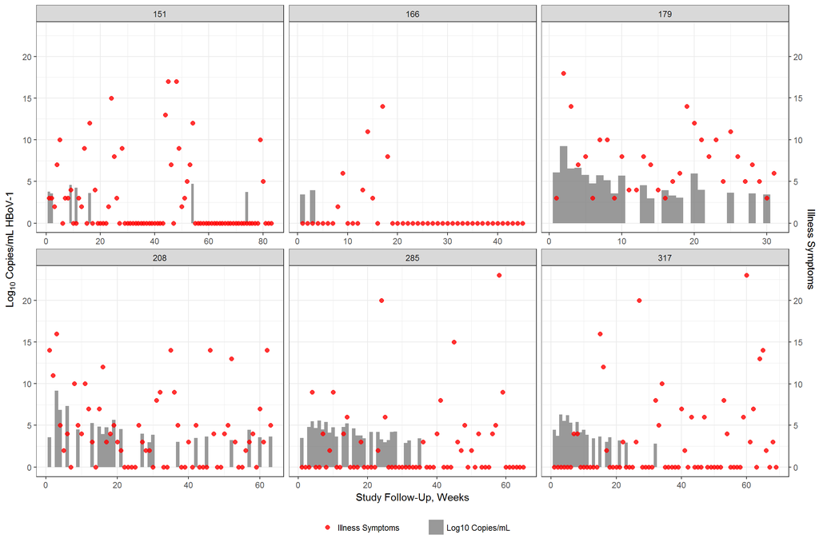

```r
sec.axis <- sec_axis(~./1, name = "Illness Symptoms")
ill.data$def.1 %>%
  filter(id %in% c(166, 285, 179, 317, 208, 151)) %>%
  ggplot(aes(x = time)) %>%
  add(geom_bar(aes(y = log_q_per_ml, fill = "Log10 Copies/mL"),
               stat = "identity", alpha = 0.8, width = 1)) %>%
  add(geom_point(aes(y = ill.symptoms * 1, group = 1, color = "Illness Symptoms"),
                alpha = 0.8,
                size = 2)) %>%
  add(scale_color_manual("",
                         values = c("Log10 Copies/mL" = "grey",
                                    "Illness Symptoms" = "red"))) %>%
  add(scale_fill_manual(" ", values = "grey50")) %>%
  add(scale_y_continuous(sec.axis = sec.axis)) %>%
  add(facet_wrap(~id, scales = "free_x")) %>%
  add(theme_bw()) %>%
  add(labs(x = "Study Follow-Up, Weeks",
           y = expression(paste("Log"[10], " Copies/mL HBoV-1")))) %>%
  add(theme(legend.position = "bottom"))
```

Spaghetti plots

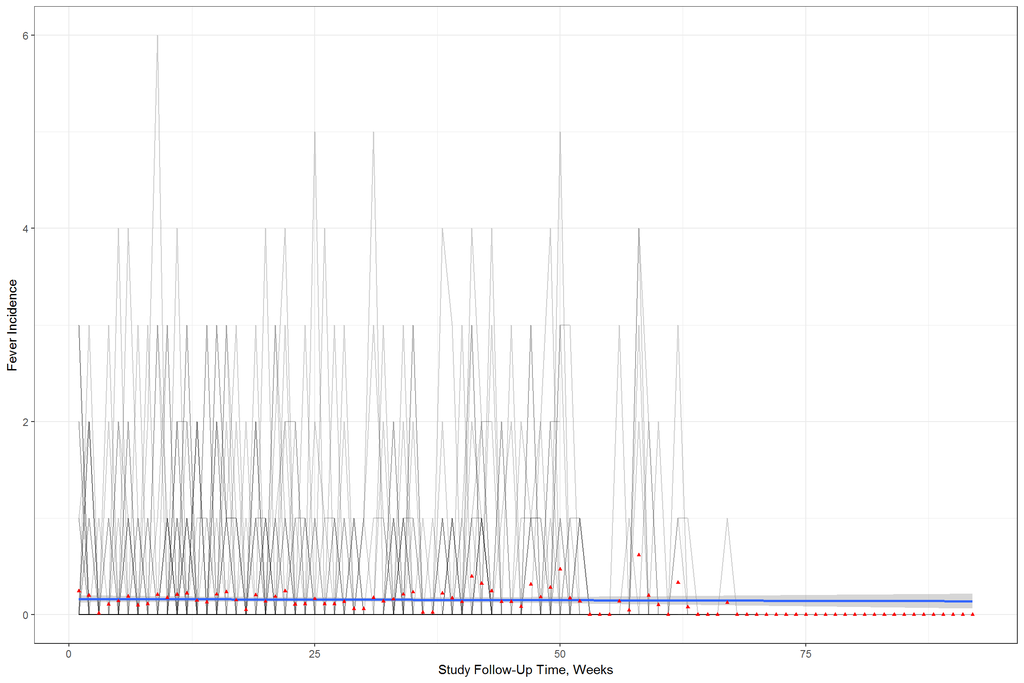

```r
fever.data$def.3 %>%
  ggplot(aes(x = time, y = fever, group = id)) %>%
  add(geom_line(alpha = 0.2)) %>%
  add(geom_smooth(aes(group = 1),
                  method = "glm")) %>%
  add(stat_summary(aes(group = 1),
                   geom = "point",
                   fun.y = mean,
                   shape = 17,
                   size = 1,
                   color = "red")) %>%
  add(labs(x = "Study Follow-Up Time, Weeks",
           y = "Fever Incidence")) %>%
  add(theme_bw())
```

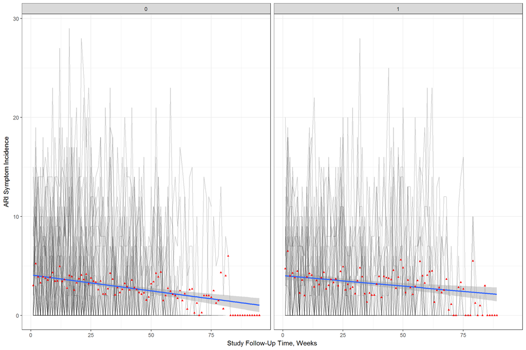

```r
ill.data$def.1 %>%
  ggplot(aes(x = time, y = ill.symptoms, group = id)) %>%
  add(geom_line(alpha = 0.2)) %>%
  add(geom_smooth(aes(group = 1),
                  method = "glm")) %>%
  add(stat_summary(aes(group = 1),
                   geom = "point",
                   fun.y = mean,
                   shape = 17,
                   size = 1,
                   color = "red")) %>%
  add(facet_wrap(~siblings)) %>%
  add(labs(x = "Study Follow-Up Time, Weeks",
           y = "ARI Symptom Incidence")) %>%
  add(theme_bw())
```

Visually, this is very difficult to assess any effect whatsoever what with the abundance of zeros and all. Coefficients from models may be able to tell us a little more.

### Data for plots of mean and bootstrapped CI

```r
levels <- c(0, 1)
vars <- c("day_care","female","siblings")
labels <- list(dc_labels = c("No Daycare", "Daycare"),
               gen_labels = c("Male", "Female"),
               sib_labels = c("No siblings", "Siblings"))

factorEr <- function(df, vars, levels, labels) {
  for (i in 1:length(vars)) {
    df[,vars[i]] <- factor(df[,vars[i]],
                           levels = levels,
                           labels = labels[[i]])
  }
  df
}

stMeansCIs <- function(df, vars, symp, levels, labels) {
  require(Hmisc)
  st_names <- c(vars, symp, "Lower","Upper")
  # without symp == 0 (non-zero data)
  t1 <- df[df[,symp] > 0, ]
  llist <- llist(t1[,vars[1]], t1[,vars[2]], t1[,vars[3]])
  s.t1 <- Hmisc::summarize(t1[,symp],
                           by = llist,
                           FUN = smean.cl.boot,
                           conf.int = 0.80)
  colnames(s.t1) <- st_names
  s.t1 <- factorEr(s.t1, vars, levels, labels)
  # zero vs. non-zero data
  t2 <- df
  llist <- llist(t2[,vars[1]], t2[,vars[2]], t2[,vars[3]])
  s.t2 <- Hmisc::summarize(t2[,symp] > 0,
                           by = llist,
                           FUN = smean.cl.boot,
                           conf.int = 0.80)
  colnames(s.t2) <- st_names
  s.t2 <- factorEr(s.t2, vars, levels, labels)
  list(s.t1 = s.t1, s.t2 = s.t2)
}

st.def1 <- stMeansCIs(fever.dat.def.1,
                      vars = vars,
                      symp = "fever",
                      levels = levels,
                      labels = labels)

st.def2 <- stMeansCIs(fever.dat.def.2,
                      vars = vars,
                      symp = "fever",
                      levels = levels,
                      labels = labels)

st.def3 <- stMeansCIs(fever.dat.def.3,
                      vars = vars,
                      symp = "fever",
                      levels = levels,
                      labels = labels)
```

To plot M and CI via lattice, we’ll use the panel.errbars function from memisc package

[figure not shown]

[figure not shown]

[figure not shown]

```r
# png("S:/MartinEpi/Analysis/Bocavirus Persistence Modeling/plots and figures/daycare_sibs_gender_fevers1.png",
#     width = 7, height = 7, units = "in", res = 500)
# plotBootCI(st.def1)
# dev.off()
```

This time now by symptoms over time

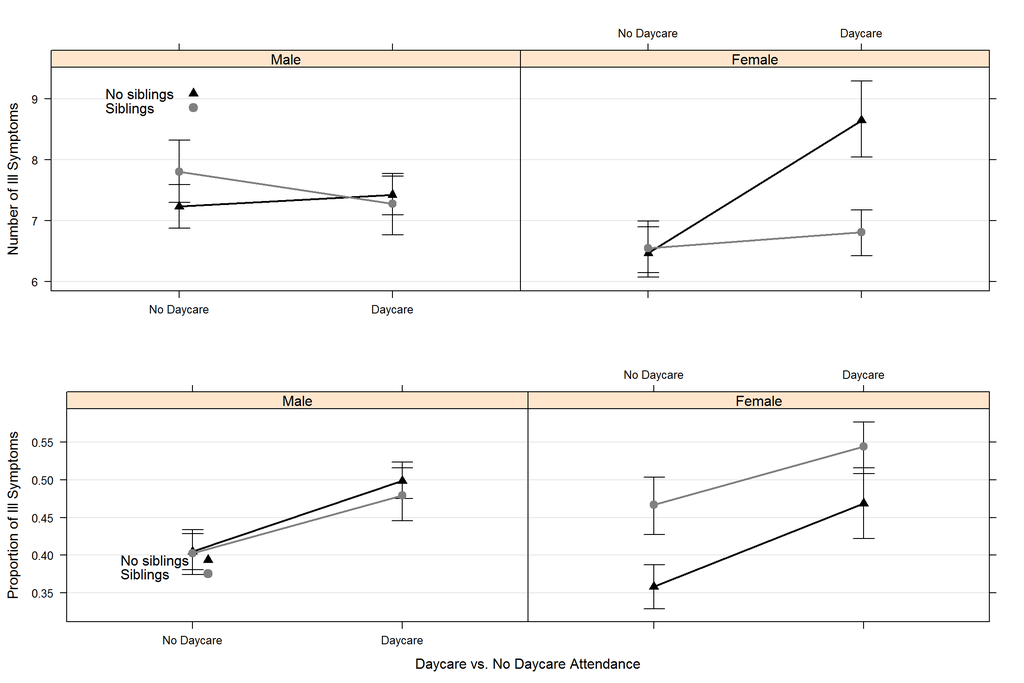

```r
st.def1 <- stMeansCIs(ill.dat.def.1,
                      vars = vars,
                      symp = "ill.symptoms",
                      levels = levels,
                      labels = labels)

st.def2 <- stMeansCIs(ill.dat.def.2,
                      vars = vars,
                      symp = "ill.symptoms",
                      levels = levels,
                      labels = labels)

st.def3 <- stMeansCIs(ill.dat.def.3,
                      vars = vars,
                      symp = "ill.symptoms",
                      levels = levels,
                      labels = labels)

xlabel <- c("", "Daycare vs. No Daycare Attendance")
ylabel <- c("Number of Ill Symptoms", "Proportion of Ill Symptoms")
plotBootCI(st.def1, symp = "ill.symptoms", xlabel = xlabel, ylabel = ylabel)
```

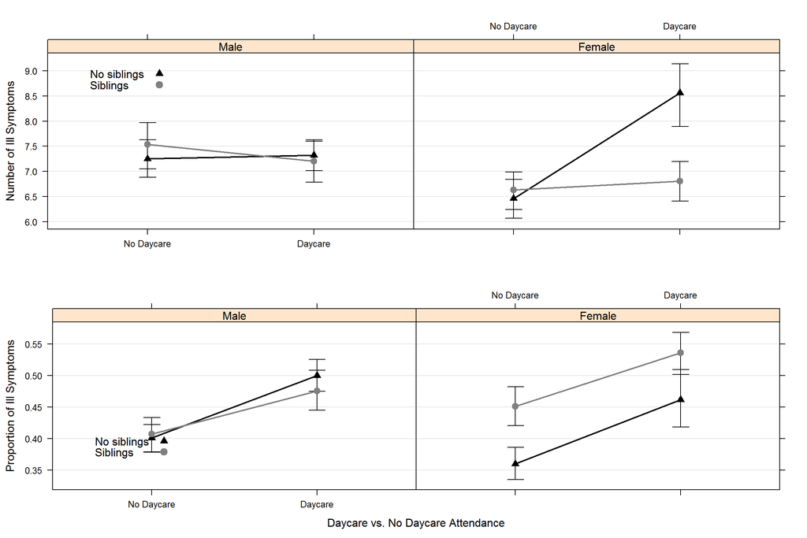

```r
plotBootCI(st.def2, symp = "ill.symptoms", xlabel = xlabel, ylabel = ylabel)
```

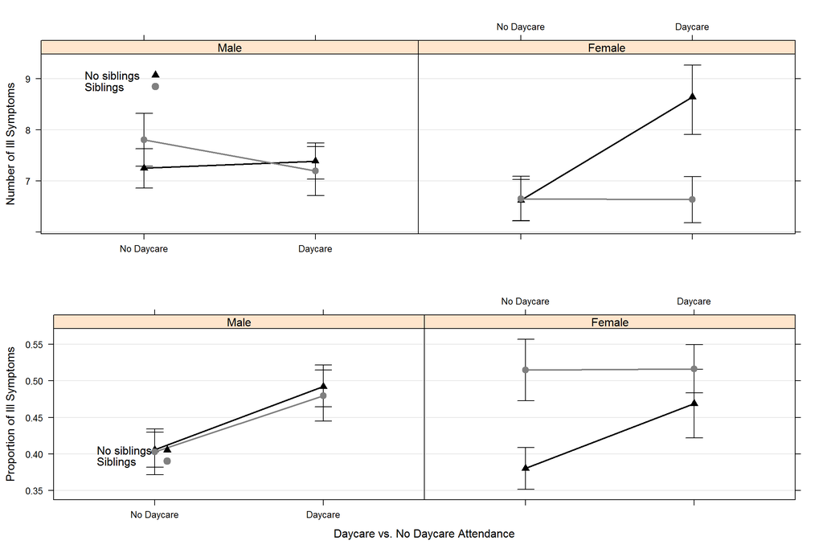

```r
plotBootCI(st.def3, symp = "ill.symptoms", xlabel = xlabel, ylabel = ylabel)
```